# HW4

박찬영

2024-11-30

```r
library(tidyverse)
```

### Textbook(1st) 19.2.1 problem 4

write your own functions to compute the variance and skewness of a numeric vector.
Variance is defined as
$$\text{Var}(x) = \frac{1}{n-1} \sum_{i=1}^n (x_i - \bar{x})^2$$
where $\bar{x} = {\sum_{i=1}^n x_i}/n$ is the sample mean.
Skewness is defined as
$$\text{Skew}(x) = \frac{\frac{1}{n-2} \left( \sum_{i=1}^n (x_i - \bar{x})^3 \right)}{\text{Var}(x)^{3/2}}.$$

```r
my_var <- function(x) {
  if (!is.numeric(x)) {
    stop("input numeric vector")
  }
  y <- na.omit(x)
  bary <- mean(y)
  vary <- sum((y - bary)^2) / (length(y) - 1)
  return(vary)
}

x <- rnorm(100)
var(x)
```

```
## [1] 0.9984141
```

```r
my_var(x)
```

```
## [1] 0.9984141
```

```r
my_skew <- function(x) {
  if (!is.numeric(x)) {
    stop("input numeric vector")
  }
  y <- na.omit(x)
  bary <- mean(y)
  u <- sum((y - bary)^3) / (length(y) - 2)
  vary <- sum((y - bary)^2) / (length(y) - 1)
  skew <- u / vary^(3 / 2)
  return(skew)
}
e1071::skewness(x)
```

```
## [1] 0.008582935
```

```r
my_skew(x)
```

```
## [1] 0.008758097
```

### Textbook(1st) 19.2.1 problem 5

Write `both_na()`, a function that takes two vectors of the same length and returns the number of positions that have an `NA` in both vectors.

```r
both_na <- function(x, y) {
  if (length(x) != length(y)) {
    stop("길이가 같은 벡터를 입력하세요.")
  }
  na_x <- is.na(x)
  na_y <- is.na(y)
  logic <- na_x * na_y
  pos <- c()
  for (i in seq_len(length(x))){
    if (logic[i] == 1) {
      pos <- c(pos, i)
    }
  }
  return(pos)
}
both_na(c(1, NA, 2, 3, NA, 8, NA), c(NA, NA, 3, 4, NA, 8, 10))
```

```
## [1] 2 5
```

### Textbook(1st) 19.4.4 problem 4

How could you use `cut()` to simplify this set of nested if-else statements?

```r
if (temp <= 0) {
  "freezing"
} else if (temp <= 10) {
  "cold"
} else if (temp <= 20) {
  "cool"
} else if (temp <= 30) {
  "warm"
} else {
  "hot"
}
```

How would you change the call to `cut()` if I’d used `<` instead of `<=`? What is the other chief advantage of `cut()` for this problem? *(Hint: what happens if you have many values in `temp`?)*

```r
how_temp <- function(temp) {
  cut(
    temp,
    breaks = c(-Inf, 0, 10, 20, 30, Inf),
    labels = c("freezing", "cold", "cool", "warm", "hot"),
    right = TRUE
  )
}

how_temp(11)
```

```
## [1] cool
## Levels: freezing cold cool warm hot
```

```r
how_temp(30)
```

```
## [1] warm
## Levels: freezing cold cool warm hot
```

```r
how_temp(c(-2, -5, 4, 12, 45))
```

```
## [1] freezing freezing cold     cool     hot
## Levels: freezing cold cool warm hot
```

<=가아니라 < 이면 cut 함수의 right 인수를 FALSE로 바꾸면 경계값의 오른쪽을 포함하지 않아서 같은 의미가 된다.  
단순히 주어진 if_else chunk는 단일 벡터를 받아 단일 벡터를 출력하지만 cut으로 범주형 변수를 이용해 구현하면 벡터의 요소가 여러개여도 각각의 요소에 대해서 대응되는 문자열을 출력할 수 있다.

### Textbook(1st) 21.2.1 problem 2

Eliminate the for loop in each of the following examples by taking advantage of an existing function that works with vectors:

```r
out <- ""
for (x in letters) {
  out <- stringr::str_c(out, x)
}

x <- sample(100)
sd <- 0
for (i in seq_along(x)) {
  sd <- sd + (x[i] - mean(x)) ^ 2
}
sd <- sqrt(sd / (length(x) - 1))

x <- runif(100)
out <- vector("numeric", length(x))
out[1] <- x[1]
for (i in 2:length(x)) {
  out[i] <- out[i - 1] + x[i]
}
```

```r
#1
str_c(letters, collapse = "")
```

```
## [1] "abcdefghijklmnopqrstuvwxyz"
```

```r
str_flatten(letters)
```

```
## [1] "abcdefghijklmnopqrstuvwxyz"
```

```r
#2
x <- sample(100)
sd <- sqrt(sum((x - mean(x))^2) / (length(x) - 1))
sd
```

```
## [1] 29.01149
```

```r
#3
x <- runif(100)
cumsum(x)
```

```
##   [1]  0.6481838  0.9193915  1.5745525  2.4558201  3.4153042  3.4579235
##   [7]  3.8681807  3.9770848  4.3668735  4.7627927  5.6421299  6.1492208
##  [13]  6.7158506  6.8163321  7.3210833  8.1177199  8.4704300  8.7171951
##  [19]  9.2831017  9.6881199 10.0576507 11.0439362 11.5515721 11.7569861
##  [25] 12.2240258 12.7913014 13.7832777 14.1837079 14.4323022 15.0180856
##  [31] 15.8158556 16.4129051 16.7937761 17.7893628 18.7850123 19.2185186
##  [37] 19.5055071 19.7749680 20.0693703 20.5336752 21.3973739 22.1220788
##  [43] 22.9989325 23.6291976 23.8539793 24.3023492 24.3789210 25.1938329
##  [49] 25.8715652 26.0915187 26.6592697 27.3966727 28.0618156 28.3426549
##  [55] 28.9665803 29.5615179 30.5358291 30.8410241 31.4727496 31.9313394
##  [61] 32.7310720 33.6314026 34.3825654 35.3467409 35.5298629 36.2132026
##  [67] 36.4093394 36.6552550 37.0134746 37.1002488 37.1879011 37.3379763
##  [73] 37.3435218 38.0622409 38.3988248 38.5994355 38.9834635 39.1366856
##  [79] 39.9920434 40.4966756 40.8536703 41.2082337 41.4665452 41.7546063
##  [85] 42.5223835 42.5865361 43.1430271 44.1233510 45.0002899 45.7194547
##  [91] 46.6598234 47.3360873 48.1832036 48.7237546 49.3473036 49.6171815
##  [97] 49.9348831 50.2721674 50.7502641 51.0680693
```

### Textbook(1st) 21.4.1 problem 1

Read the documentation for `apply()`. In the 2d case, what two for loops does it generalise?

행별로 돌리는 for루프와 열별로 돌리는 for루프가 일반화 된다.

### Textbook(1st) 21.5.3 problem 2

How can you create a single vector that for each column in a data frame indicates whether or not it’s a factor?

```r
map_lgl(mtcars, is.factor)
```

```
##   mpg   cyl  disp    hp  drat    wt  qsec    vs    am  gear  carb
## FALSE FALSE FALSE FALSE FALSE FALSE FALSE FALSE FALSE FALSE FALSE
```

```r
map_lgl(diamonds, is.factor)
```

```
##   carat     cut   color clarity   depth   table   price       x       y       z
##   FALSE    TRUE    TRUE    TRUE   FALSE   FALSE   FALSE   FALSE   FALSE   FALSE
```

### Textbook(1st) 23.2.1 problem 2

One way to make linear models more robust is to use a different distance measure.  
For example, instead of root-mean-squared distance, you could use mean-absolute distance:

```r
measure_distance <- function(mod, data) {
  diff <- data$y - (mod[1] + data$x * mod[2])
  mean(abs(diff))
}
```

Use optim() to fit this model to the simulated data above and compare it to the linear model.

```r
library(modelr)

measure_distance <- function(mod, data) {
  diff <- data$y - (mod[1] + data$x * mod[2])
  mean(abs(diff))
}

best <- optim(c(0, 0), measure_distance, data = sim1)
best$par
```

```
## [1] 4.364852 2.048918
```

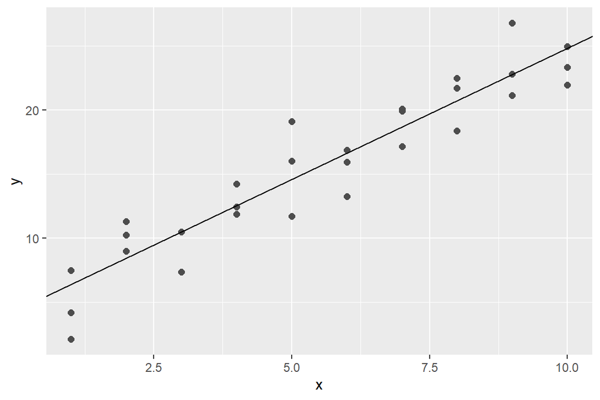

```r
ggplot(sim1, aes(x, y)) +
  geom_point(size = 2, colour = "grey30") +
  geom_abline(intercept = best$par[1], slope = best$par[2])
```

measure_distance를 root-mean-squared distance로 했을 때의 회귀계수 4.222248 2.051204와 다르게 4.364852 2.048918이 나왔다. 그래프를 보면 아웃라이어에 더 둔감하게 반응한다.

### Textbook(1st) 23.3.3 problem 1

Instead of using `lm()` to fit a straight line, you can use `loess()` to fit a smooth curve. Repeat the process of model fitting, grid generation, predictions, and visualisation on `sim1` using `loess()` instead of `lm()`. How does the result compare to `geom_smooth()`?

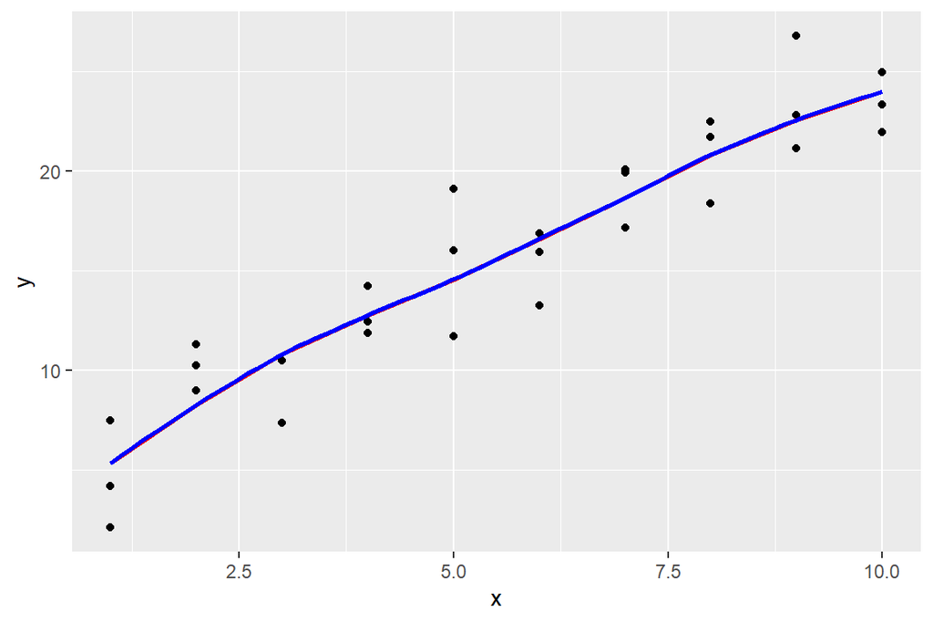

```r
grid <- sim1 %>%
  data_grid(x)

lmod <- loess(y ~ x, data = sim1)
pred <- grid %>%
  add_predictions(lmod)

ggplot(sim1, aes(x = x, y = y)) +
  geom_point(aes(y = y)) +
  geom_line(aes(y = pred), data = pred, colour = "red", size = 1) +
  geom_smooth(color = "blue", se = FALSE)
```

빨간 선(직접 모델링)과 파란 선(geom_smooth)는 거의 겹치는 것을 알 수 있다.

### Textbook(1st) 23.4.5 problem 3

Using the basic principles, convert the formulas in the following two models into functions. *(Hint: start by converting the categorical variable into 0-1 variables.)*

```r
mod1 <- lm(y ~ x1 + x2, data = sim3)
mod2 <- lm(y ~ x1 * x2, data = sim3)
```

```r
# mod1
x <- model.matrix(y ~ x1 + x2, sim3)
y = sim3$y
beta1 <- solve(t(x) %*% x) %*% t(x) %*% y
beta1
```

```
##                   [,1]
## (Intercept)  1.8716659
## x1          -0.1967378
## x2b          2.8878108
## x2c          4.8057359
## x2d          2.3595867
```

```r
# mod2
x2 <- model.matrix(y ~ x1 * x2, sim3)
beta2 <- solve(t(x2) %*% x2) %*% t(x2) %*% y
beta2
```

```
##                    [,1]
## (Intercept)  1.30124266
## x1          -0.09302444
## x2b          7.06937991
## x2c          4.43089525
## x2d          0.83455115
## x1:x2b      -0.76028528
## x1:x2c       0.06815284
## x1:x2d       0.27727920
```

### Textbook(2nd) 26.2.8 problem 1

Practice your `across()` skills by:

1. Computing the number of unique values in each column of `palmerpenguins::penguins`.

```r
palmerpenguins::penguins %>%
  summarise(across(everything(), ~length(unique(.))))
```

```
## # A tibble: 1 × 8
##   species island bill_length_mm bill_depth_mm flipper_length_mm body_mass_g
##     <int>  <int>          <int>         <int>             <int>       <int>
## 1       3      3            165            81                56          95
## # ℹ 2 more variables: sex <int>, year <int>
```

2. Computing the mean of every column in `mtcars`.

```r
mtcars %>%
  summarise(across(everything(), mean))
```

```
##        mpg    cyl     disp       hp     drat      wt     qsec     vs      am
## 1 20.09062 6.1875 230.7219 146.6875 3.596563 3.21725 17.84875 0.4375 0.40625
##     gear   carb
## 1 3.6875 2.8125
```

3. Grouping `diamonds` by `cut`, `clarity`, and `color` then counting the number of observations and computing the mean of each numeric column.

```r
diamonds %>%
  group_by(cut, clarity, color) %>%
  summarise(
    n = n(),
    across(where(is.numeric), mean)
  )
```

```
## # A tibble: 276 × 11
## # Groups:   cut, clarity [40]
##    cut   clarity color     n carat depth table price     x     y     z
##    <ord> <ord>   <ord> <dbl> <dbl> <dbl> <dbl> <dbl> <dbl> <dbl> <dbl>
##  1 Fair  I1      D         4 1.88   65.6  56.8 7383   7.52  7.42  4.90
##  2 Fair  I1      E         9 0.969  65.6  58.1 2095.  6.17  6.06  4.01
##  3 Fair  I1      F        35 1.02   65.7  58.4 2544.  6.14  6.04  4.00
##  4 Fair  I1      G        53 1.23   65.3  57.7 3187.  6.52  6.43  4.23
##  5 Fair  I1      H        52 1.50   65.8  58.4 4213.  6.96  6.86  4.55
##  6 Fair  I1      I        34 1.32   65.7  58.4 3501   6.76  6.65  4.41
##  7 Fair  I1      J        23 1.99   66.5  57.9 5795.  7.55  7.46  4.99
##  8 Fair  SI2     D        56 1.02   64.7  58.6 4355.  6.24  6.17  4.01
##  9 Fair  SI2     E        78 1.02   63.4  59.5 4172.  6.28  6.22  3.96
## 10 Fair  SI2     F        89 1.08   63.8  59.5 4520.  6.36  6.30  4.04
## # ℹ 266 more rows
```